LUISS GUIDO CARLI Undergraduate course of Management and Artificial Intelligence - 2nd Year Machine Learning - Academic Year 2025/2026

# Compliance Radar

**Team Members** Di Renzo Carla ID 323411 Moriondo Tommaso ID 316331 Pazienza Lorenzo ID 308741 Raimondo Eleonora ID 321521

# **[Section 1] Introduction**

This project develops a predictive and interpretive framework designed to identify potential compliance risks within an organisation. Using the *org_compliance_data.db* dataset, which brings together operational, audit, reporting, financial, and employee-related indicators, the analysis aims to highlight departments that may be more exposed to compliance challenges and to characterize the organisational conditions associated with such risks.

Formulated as a binary classification task with `is_at_risk` $\,\in\, \{0,1\}$, the model achieves evidence-based insights intended to strengthen internal accountability and support ethical, informed decision-making across the organisation.

# **[Section 2] Methods**

## **2.1 Dataset Analysis**

The dataset includes a wide range of departmental indicators, such as: - Audit outcomes - Operational exposures - Governance support measures - Reporting behavior - Training participation - Employee engagement metrics

Two structural factors strongly influence the methodological design: 1. Class imbalance in the target variable. 2. Surveillance bias, where at-risk departments show artificially lower missingness due to more intensive auditing.

This requires careful handling of missing values and strong leakage control.

## **2.2 Exploratory Data Analysis (EDA)**

The exploratory phase examines:

- Numerical variable distributions (histograms, box plots)
- Categorical frequency patterns
- Row-wise missingness scoring
- The relationship between missingness levels and risk status, reinforcing evidence of surveillance bias

### Figure 1 – Correlation with the Target Variable

Below we report the Pearson correlations between each numerical feature and the target `is_at_risk`.

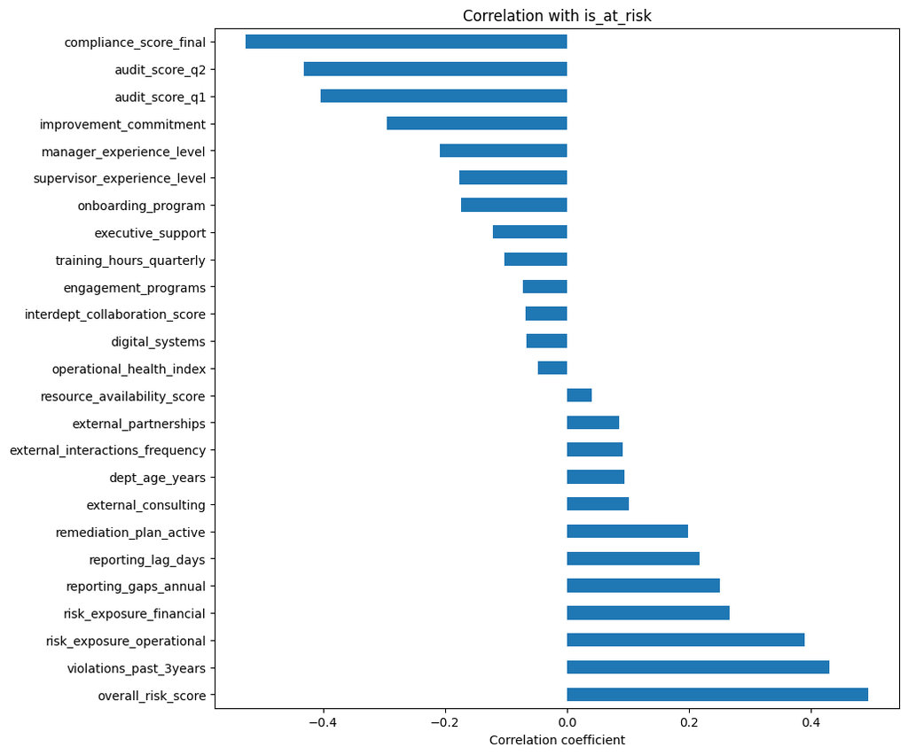

Strong negative correlations correspond to audit-related leakage, later removed from the modelling pipeline.

### Figure 2 – Missingness Patterns and Surveillance Bias

Missing values differ systematically between at-risk and not-at-risk departments, confirming surveillance bias.

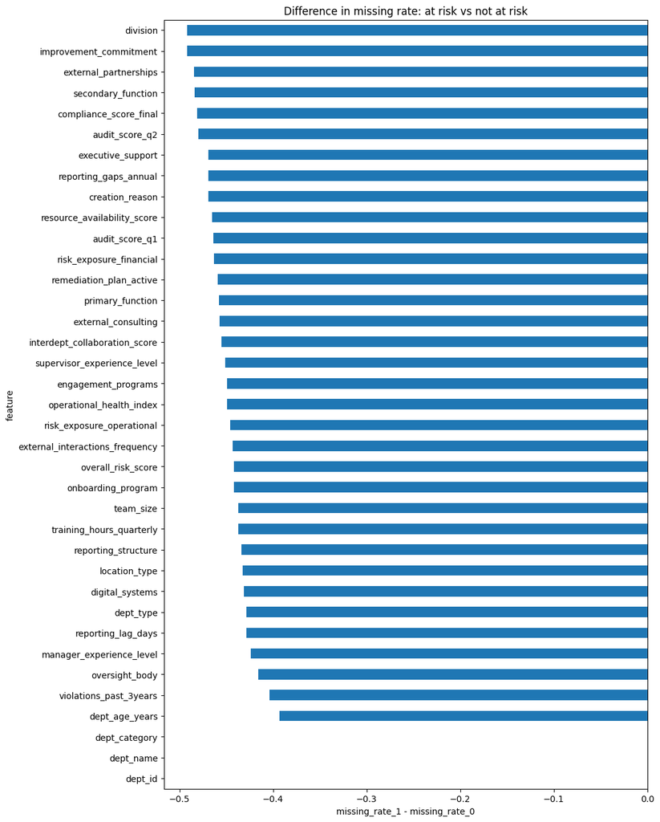

At-risk departments systematically show fewer missing values due to increased audit scrutiny.

## **2.4 Pre-processing**

### **Imputation**

- Binary variables -> Mode
- Ordinal variables -> Median
- Continuous variables -> Median
- Categorical Feature -> “Missing”

## Feature Engineering**

To represent organisational dynamics more explicitly, several composite indicators are constructed: - Governance Support Index - Operational Complexity - Training Efficiency - Experience Gap - Risk Gap

These engineered features are fully leakage-free and provide interpretable signals relevant to managerial decision-making.

##2.5 model preparation

### **Data Splitting**

A stratified split preserves class proportions across folds.

### **Encoding**

Categorical variables are transformed using target encoding with smoothing parameter `\alpha = 10`.

### **Scaling** (only for logistic regression)

Numerical features are standardized using z-score scaling within the logistic regression pipeline.

## **2.6 Model Design and Training Pipeline**

Three modelling approaches are implemented within a unified scikit-learn pipeline: - Logistic Regression (selected final model) - Decision Tree (CART) - Random Forest (RF)

### **Logistic Regression**

Hyperparameters explored: - $C \in \{0.01, 0.1, 1, 10\}$ - Penalties: $\ell_1$ and $\ell_2$

Best configuration: - Penalty: $\ell_2$ - $C = 0.01$

### **Decision Tree (CART)**

Grid search explores: - Maximum depth - Minimum samples per split - Minimum samples per leaf - Maximum features

### **Random Forest**

Hyperparameter search considers: - Number of trees - Maximum depth - Maximum features - Node-splitting constraints

## **2.7 Metrics evaluation Setup**

Metrics evaluated: - ROC-AUC - Accuracy - Precision - Recall - F1-score

Additional analysis includes: - precision–recall curves - decision-threshold evaluation

## **2.8 Environment Setup**

The repository includes: - `main.ipynb` — Main notebook - `images/` — Figures generated during analysis - `requirements.txt` - Environment and setup

### Environment and setup

This project was developed and tested with **Python 3.13.9** using a dedicated virtual environment (`.venv`). All required packages are listed in `requirements.txt`.

To reproduce the environment: #### **Create and activate the virtual environment** From the project root folder (where `main.ipynb` and `requirements.txt` are located): `python -m venv .venv`

#### **Activate the environment:**

- **Windows (PowerShell)** `.\.venv\Scripts\Activate.ps1`
- **Windows (cmd)** `.\.venv\Scripts\activate`
- **macOS / Linux** `source .venv/bin/activate`

#### **Install the dependencies**

With the virtual environment active: `pip install -r requirements.txt`

#### **(Optional) Register the kernel for Jupyter / VS Code**

`python -m ipykernel install --user --name orgcompliance-ml --display-name "Org Compliance ML"`

In VS Code, open **main.ipynb** and select the kernel “Org Compliance ML (Python 3.13.9)” (or the ‘.venv’ environment)

#### **Run the notebook**

Once the kernel is selected, run **main.ipynb** from top to bottom to reproduce all analyses and models.

### Figure 3 – Pipeline Flowchart

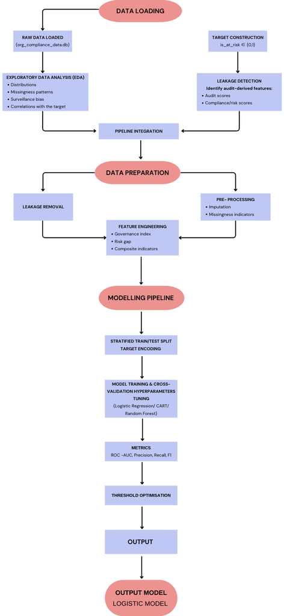

A schematic representation of preprocessing, feature engineering, cross-validation and model selection.

# **[Section 3] Experimental Design**

## 3. Experimental Design

Our experiments were based on two things: 1. Develop an efficient Compliance Radar to control risky departments. 2. Measure the extent to which performance of model is conditional on surveillance-related signals (patterns of missingness and remedial action).

In every experiment we take the following pipeline: - Stratified train test split on is at risk - Target-encoded features which are leak-free (fitted on the training set only) - Model selection or stratified K-fold cross-validation on the training set - Final test on the held-out test set

## **3.1 Experiment 1 — Models Training and Evaluation with full set of features**

The subject in this experiment was to compare three models with the complete set of features.

**Main purpose.** Compare diverse trained models on the complete feature-set, including missing-value, flags and the remediation plan active variable, and choose a primary Compliance Radar model.

**Methods.** - Standardized Regression (of Logistic) (regularized) - decision tree classifier (CART) - Random Forest classifier

On the training-set, we tune each model by stratified K-fold cross-validation hyperparameters (strength of regularization and type penalty of LR; depth and splitting CART parameters; the number of trees, depth and leaf parameters of RF).

**Evaluation metrics** We report on validation folds and on the test set: - ROC-AUC (general discriminating ability) - F1-score, precision and recall of the at-risk group ( is at-risk = 1) - Confusion matrix and accuracy in it are complete

This experiment demonstrates that a regularized Logistic Regression already gives a powerful and interpretable Compliance Radar, and CART and Random Forest provide non-linear benchmarks.

## **3.2 Experiment 2 — Threshold Optimization**

In the second experiment, threshold optimization of Logistic Regression was applied to the data collected in experiment 1 and the results were compared with the initial analysis.

**Main purpose** Tune the decision level of the tuned Logistic Regression model in order to represent the better cost of business of missing at-risk departments (false negatives) versus triggering false positives (additional warnings).

**Baseline** - The 0.5 default threshold on the probability forecast. - P (is at risk = 1), which was used in Experiment 1

**Methods** With the tuned Logistic Regression of Experiment 1: - Calculate individualized predictions on the test set - Assess a grid of decision thresholds (e.g. between 0.1 and 0.9) - At every threshold, calculate precision, recall, F1-score and the confusion matrix

**Evaluation metrics** - Recall on the at-risk class (priority: do not miss really risky departments) - Accuracy on the at-risk group (modulate the volume of false notifications) - F1-score as a summary of the trade-off

We will then choose an operating threshold which will retain a high recall at low cost. accuracy at an acceptable degree. It is the primary model, this calibrated Logistic Regression presented in the Results section.

## **3.3 Experiment 2 Models Training and Evaluation without Surveillance Bias**

The experiment 3 involved a sensitivity analysis of the influence of surveillance bias on the results of the experiment.

**Main purpose** Determine the extent of model performance that relies on the behavior of monitoring (surveillance bias) using comparison between models trained with and without variables encoding activity of monitoring and remediation.

**Baselines** - Experiment 1 best Logistic Regression and the best random forest models (all features, including missingness flags and remediation plan active).

**Methods** - Weed out a diminished set of features by dropping: - missing-value indicator features; - the active remediation plan variable, which is named remediation plan active. - Retrain and retune: - Logistic Regression (cross-validation procedure as in Experiment 1); - Random Forest (equivalent hyperparameter search procedure). - Re-use the threshold-selection reasoning of Experiment 2 on the shrunk models.

**Evaluation metrics** On each of our compared models: between full and reduced feature sets: - test ROC-AUC - F1-score, accurate and recalls on the at-risk class - modification of the confusion matrix, particularly of the number of missed at-risk departments.

# **[Section 4] Results**

## **4.1 Models trained on the full feature set (with missing flags)**

In this first block we train and tune three models on the full feature set, including: - Engineered numerical variables  
- Target-encoded categorical variables  
- Missing-value flags  
- `remediation_plan_active` and other monitoring-related features

The final comparison is based on the test set and uses the thresholds selected in the notebook (Section 16.6):

Model Threshold | ROC-AUC | Precision (risk=1) | Recall (risk=1) | F1 (risk=1) Logistic Regression 0.53 | 0.871 | 0.686 | 0.600 | 0.640 CART (Decision Tree) 0.50 | 0.857 | 0.492 | 0.775 | 0.602 Random Forest (baseline) 0.50 | 0.926 | 0.839 | 0.650 | 0.732 Random Forest (optimized) 0.42 | 0.926 | 0.725 | 0.725 | 0.725

### Figure 4 – Model Comparison Surveillance Bias

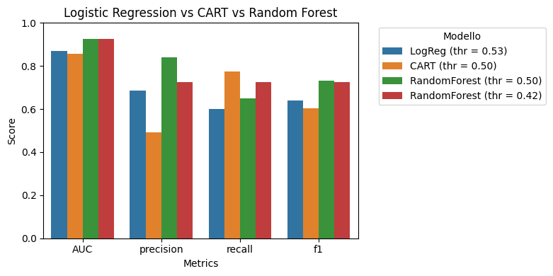

**Logistic Regression (full feature set)**  
- Regularized LR with class weights balanced.  
- Good overall discrimination (AUC = $\alpha \approx 0.87$).  
- With a threshold of $\alpha \approx 0.53$, it achieves precision = $\alpha \approx 0.69$ and recall = $\alpha \approx 0.60$ on at-risk departments, giving a balanced but slightly conservative radar.

**CART (Decision Tree)**  
- Similar AUC ($\alpha \approx 0.86$), but with a different error profile:  
– High recall ($\alpha \approx 0.78$) on at-risk departments -> catches many risky units.  
– Lower precision ($\alpha \approx 0.49$) -> more false alarms.  
- Provides simple, rule-based splits but is less stable and more sensitive to small variations in the data.

**Random Forest (full feature set)**  
- Highest AUC ($\alpha \approx 0.93$).  
- At threshold 0.50, precision is high ($\alpha \approx 0.84$) but recall is moderate ($\alpha \approx 0.65$).  
- After threshold optimization (thr = $\alpha \approx 0.42$), RF reaches a balanced recall and precision of $\alpha \approx 0.73$, with F1 = $\alpha \approx 0.73$.  
- However, it remains a complex ensemble with a noticeable train–test gap, and is substantially less interpretable than Logistic Regression.

## **4.2 Interpretation of Logistic Regression coefficients (with missing flags)**

Using the full feature set (including missing flags and remediation signals), Logistic Regression provides a transparent view of which variables act as risk drivers or buffers.

The coefficient ranking (sorted by absolute value) shows the following top factors:

### Figure 5 – Logistic Regression Coefficient Analysis (Surveillance Bias)

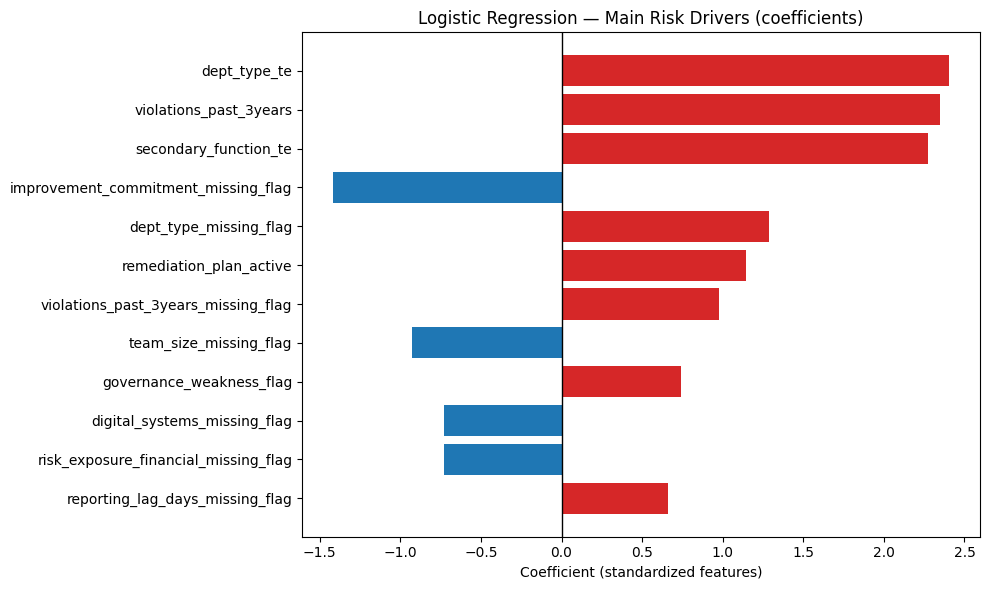

### Protective factors (negative coefficients)

Overall, the full-feature Logistic Regression confirms that: - True risk drivers (violations, risk exposure, governance weaknesses) are important - Many monitoring / missingness signals (`*_missing_flag`, `remediation_plan_active`) also carry strong weight.

This justifies a second round of modelling without missing flags, to separate underlying risk from surveillance behavior.

## **4.3 Models trained without missing-value flags**

In the second block we rebuild the models on a reduced “no-leakage” feature set, where we remove: - All missing-value indicator variables  
- Other obvious surveillance-related flags

We focus on Logistic Regression and Random Forest as the two main benchmarks.

### Logistic Regression (no missing flags)

To avoid overly skewing towards recall, the notebook searches for a balanced threshold using the precision–recall curve: - Optimal balanced threshold = $\alpha \approx 0.62$  
- At this threshold: – Precision (risk=1) = $\alpha \approx 0.72$ – Recall (risk=1) = $\alpha \approx 0.72$ – F1 = $\alpha \approx 0.72$

Cross-validation (9-fold) shows: - ROC-AUC: train = $\alpha \approx 0.91$, test = $\alpha \approx 0.89$ (gap = $\alpha \approx 0.02$)  
- F1: train = $\alpha \approx 0.70$, test = $\alpha \approx 0.67$ (small gap)  
Indicating a stable and not overfitted linear model.

**Figure 6 – Logistic Regression ROC - AUC (No-bias)**

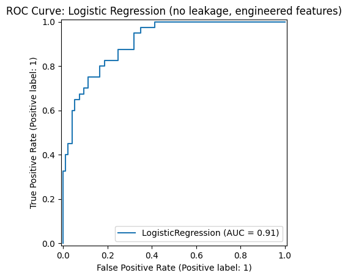

### Random Forest (no missing flags)

Using the same no-leakage feature set: - Tuned via grid search (5-fold CV) with balanced class weights - Test ROC-AUC $\alpha \approx 0.92$ at threshold 0.5 - At threshold 0.5: – Precision (risk=1) = $\alpha \approx 0.87$ – Recall (risk=1) = $\alpha \approx 0.50$ – F1 = $\alpha \approx 0.63$

Cross-validation diagnostics show: - ROC-AUC: train = $\alpha \approx 0.99$, test = $\alpha \approx 0.92$ (larger gap than LR) - F1: train = $\alpha \approx 0.82$, test = $\alpha \approx 0.68$

This indicates a more complex, higher-variance model, with stronger performance in terms of AUC but also more sensitivity and some overfitting.

### Comparison (no missing flags)

For these reasons, the no-leakage Logistic Regression is adopted as the final Compliance Radar model, while Random Forest serves as a non-linear benchmark. # **[Section 5] Conclusion**

## **5.1 Final business interpretation (Logistic Regression without missing flags)**

From the coefficient analysis on the no-leakage feature set:

### Figure 7 – Top 15 Logistic Regression Abs Value Coefficient (Risk Drivers / Buffers)

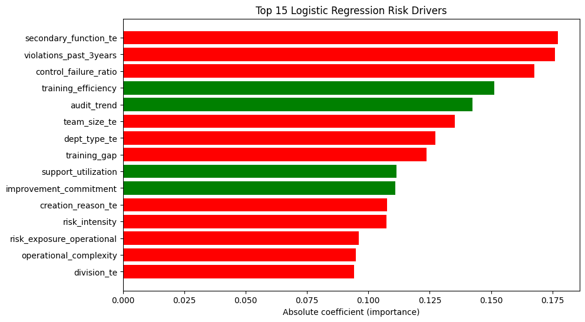

### Key risk drivers

- **Violations history**  
  `violations_past_3years` is one of the strongest positive predictors: departments with repeated past breaches are much more likely to be at risk.
- **Functional profile and role**  
  `secondary_function_te`, `dept_type_te` and `creation_reason_te` capture the fact that some functions and department types are structurally more exposed (e.g. risk-taking or control-light roles, newly created units with immature processes).
- **Control failures and risk intensity**  
  `control_failure_ratio`, `risk_intensity` and `risk_exposure_operational` all increase risk, linking operational complexity and control breakdowns directly to compliance vulnerability.
- **Training and performance gaps**  
  `training_gap` (misalignment between required and actual training) and low training efficiency are associated with higher risk.
- **Operational complexity**  
  `operational_complexity` contributes positively: more complex operations tend to be harder to control and more exposed to errors or misconduct.

### Protective factors

- **Training efficiency and improvement commitment**  
  High `training_efficiency` and strong `improvement_commitment` reduce risk: departments that convert training into concrete improvements and actively work on remediation are less likely to be flagged.
- **Audit trend and support utilization**  
  Positive `audit_trend` (improving audit results over time) and effective `support_utilization` (using central support resources) act as buffers against risk.
- **Managerial and supervisory quality**  
  Higher `manager_experience_level` and `supervisor_experience_level` correlate with lower risk, emphasizing the importance of experienced leadership.
- **Onboarding and staff development**  
  The presence of `onboarding_program` and higher `training_hours_quarterly` are associated with reduced predicted risk, indicating more mature people processes.

### Business takeaway

The final no-leakage Logistic Regression model delivers a transparent Compliance Radar that: - Flags at-risk departments based on substantive drivers (violations, exposure, complexity, governance quality, training gaps) - Avoids relying on missingness and remediation flags as shortcut proxies for surveillance intensity - Provides interpretable coefficients that can be directly mapped to actionable levers for the compliance function (strengthening training, improving governance, supporting high-exposure departments, etc.)

## **5.3 Future Work**

Potential extensions include: - Fairness analysis across departments and groups - Causal inference methods to distinguish correlation from causation - Temporal modelling, incorporating time dynamics of risk and audits - Scenario-simulation dashboards for decision-makers

Overall, this project provides a transparent and responsible foundation for compliance analytics in organizations.